# The most important features of the heart attack dataset

## by Abdelrhman Samir Eltawagny

## Investigation Overview

In this investigation, I wanted to look at the characteristics of heart attack dataset that could be used to predict their target. The main focus was on the factors that affect the incidence of heart attack

## Dataset Overview

The data contains 1024 patients and 14 features, and these features are: chest pain type , blood pressure , cholesterol as well as additional features

## Distribution of Blood pressure

The distribution of trestbps(resting blood pressure) variable looks roughly Gaussian distribution or Normal distribution

2.There are not a small number of patients suffering from high blood pressure, i.e. more than 130. These people will need to follow up with the attending physician so that this high pressure does not cause hardening of the heart arteries.

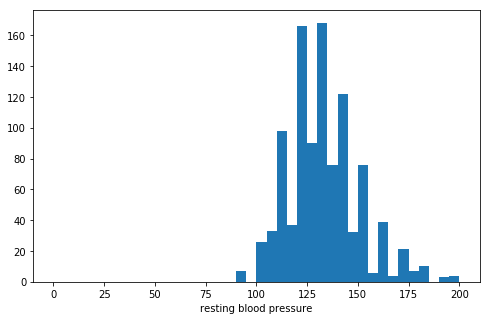

## Distribution of cholestoral

The distribution of serum cholestoral in mg/dl variable looks roughly Gaussian distribution or Normal distribution with some outliers. So we can answer the first question

1-the range of cholestoral of patients between 200 and 270 that means that the most patients in elvated level

2- There are some patients who suffer from very high levels of cholesterol, from 400 to nearly 600 mg/dl(outliers values). So these patients will need to follow up their health conditions with the attending physician, but this is not a cause for concern at all.

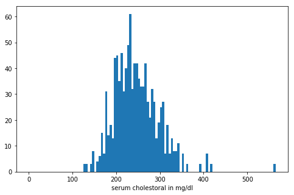

## Men vs women in having a heart attack

There are several factors for heart attack among those factors are :

- Blood pressure level
- Blood sugar level
- Heart rate

## Blood pressure level

According to Centers for Disease Control and Preventation (CDC) , high blood pressure is a major risk factor for heart disease. It is a medical condition that happens when the pressure of the blood in your arteries and other blood vessels is too high. The high pressure, if not controlled, can affect your heart and other major organs of your body, including your kidneys and brain.

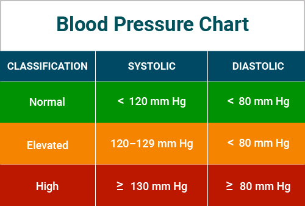

```
1    369
0    199
Name: sex, dtype: int64
```

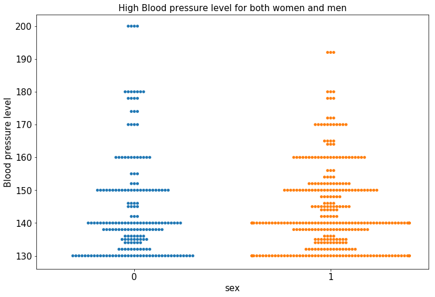

## Blood sugar level

According to **Centers for Disease Control and Preventation (CDC)** , high blood sugar can damage blood vessels and the nerves that control your heart. fasting blood sugar test measures your blood sugar after an overnight fast (not eating).

A fasting blood sugar level of 99 mg/dL or lower is normal 100 to 125 mg/dL indicates you have prediabetes and 126 mg/dL or higher indicates you have diabetes. According to **National Institute of Diabetes and Digestive and Kideny Diseases (NIDDK)** , Having diabetes means you are more likely to develop heart disease

```
sex    0    1
fbs
0    164  298
1     35   71
```

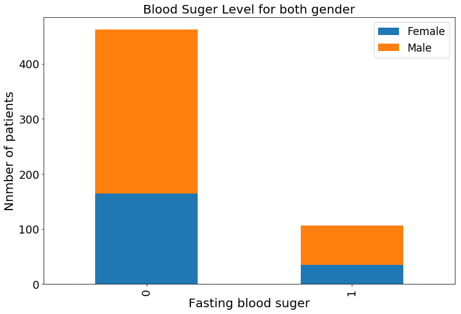

### Maximum heart rate

> Heart rate is a predictor of cardiovascular and all-cause mortality in the general population and in patients with cardiovascular disease. Increased resting heart rate multiplies risk and interferes at all stages of the cardiovascular disease continuum initiating from endothelial dysfunction and continuing via atherosclerotic lesion formation and plaque rupture to end-stage cardiovascular disease

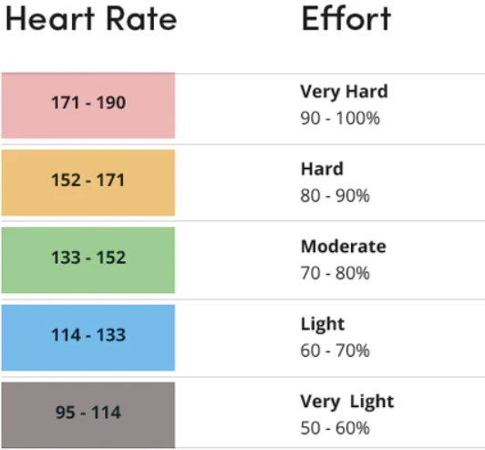

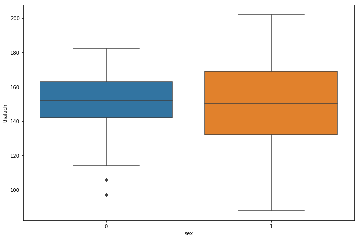